# Probability Distributions

Nick Gotelli

February 15, 2018

### Probability distributions

- stochastic versus deterministic models
- randomness = ignorance
- use in stochastic simulation modeling
- use by empiricists to generate artificial data

Random variable $X_i$ that can take on values for $i=1\dots \infty$, each with probability $p_i$.

The expectation is a weighted average, where the weights are the probablities:

$$E(X_i) = \sum_{i=1}^\infty p_i X_i$$

$$E(\sigma^2X_i) = E(\sum_{i=1}^\infty (X_i - E(X_i))^2$$

These are first and second “moments”, usually interpreted as the mean and the variance. The third moment is the skewness (asymmetry left or right), and the fourth moment is kurtosis (how fat or skinny tailed the distribution is.

### The “grammar” of probability distributions in R

- `d` gives probability density function
- `p` gives cumulative distribution function
- `q` gives quantile function (the inverse of `p`)
- `r` gives random number generation

## Create tiny histogram plotting function

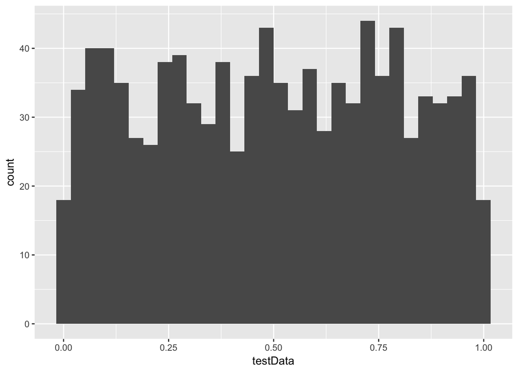

```r
library(ggplot2)

# built in function is not so great
testData <- runif(1000)
qplot(testData)
```

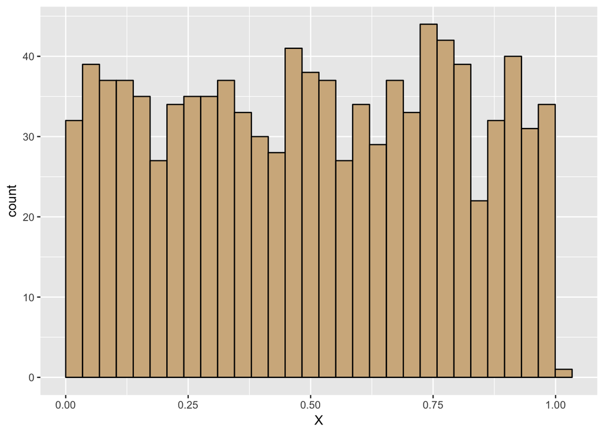

```
##    Min. 1st Qu.  Median    Mean 3rd Qu.    Max.
## 0.00037 0.24664 0.49952 0.49991 0.74879 0.99968
##       2.5%      97.5%
## 0.02806152 0.97219562
```

```r
# FUNCTION Histo
# input: xData = a numeric vector
# output: ggplot of histogram



Histo <- function(xData=runif(1000),fColor="tan") {
  z <- qplot(x=xData,color=I("black"),fill=I(fColor),xlab="X",boundary=0)

print(z)
print(summary(xData))
print(quantile(xData,probs=c(0.025,0.975)))
}

# FUNCTION iHisto
# input: xData = a numeric vector of integers
# output: ggplot of bar heights

iHisto <- function(xData=runif(1000),fColor="tan") {
z <- qplot(x=factor(xData),color=I("black"),fill=I(fColor),xlab="X")

print(z)
print(summary(xData))
print(quantile(xData,probs=c(0.025,0.975)))
}


Histo(testData)
```

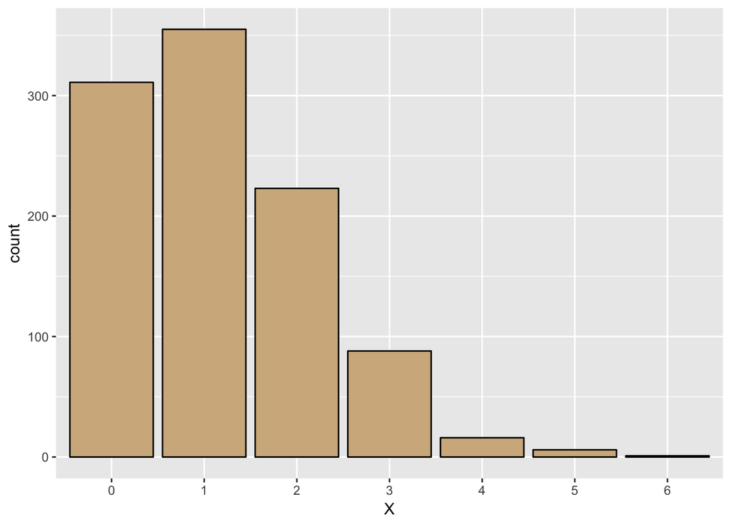

```
##    Min. 1st Qu.  Median    Mean 3rd Qu.    Max.
##   0.000   0.000   1.000   1.165   2.000   6.000
##  2.5% 97.5%
##     0     3
```

```r
testData <- rpois(n=1000,lambda=1.1)
iHisto(testData)
```

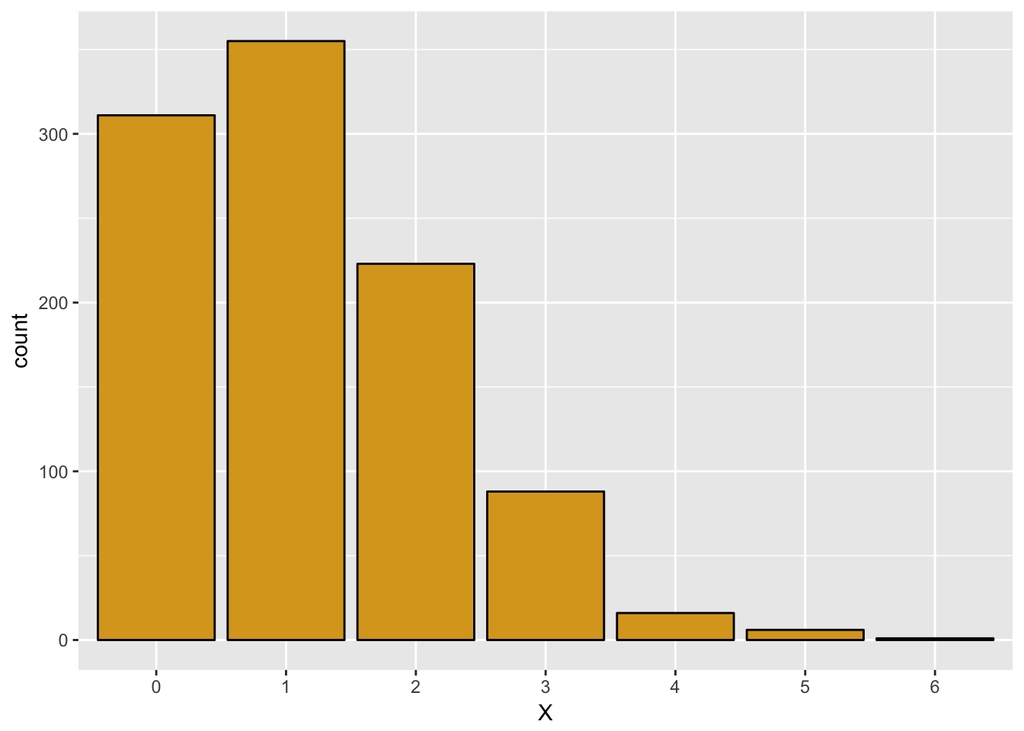

```
##    Min. 1st Qu.  Median    Mean 3rd Qu.    Max.
##   0.000   0.000   1.000   1.165   2.000   6.000
##  2.5% 97.5%
##     0     3
```

```r
iHisto(xData=testData,fColor="goldenrod")
```

### Probability distributions in R

#### Discrete distributions

- Poisson
  - Range: [0,$\infty$]
  - Parameters: size = number of trials, rate = $\lambda$
  - Interpretation: Distribution of events that occur during a fixed time interval or sampling effort with a constant rate of independent events; resembles normal with large $\lambda$, or exponential with small $\lambda$

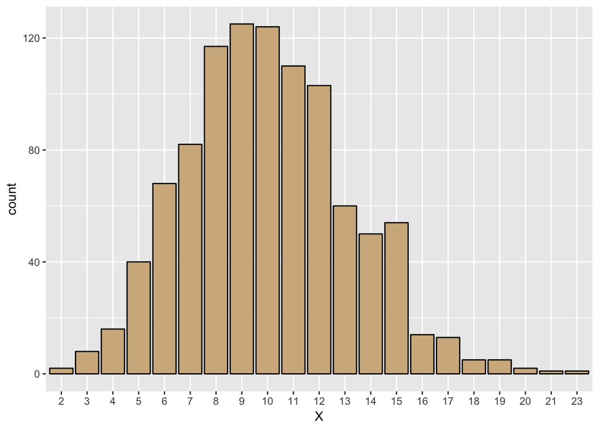

```
##    Min. 1st Qu.  Median    Mean 3rd Qu.    Max.
##    2.00    8.00   10.00   10.03   12.00   23.00
##  2.5% 97.5%
##     4    17
```

```r
x <- rpois(n=1000,lambda=10)
iHisto(x)
```

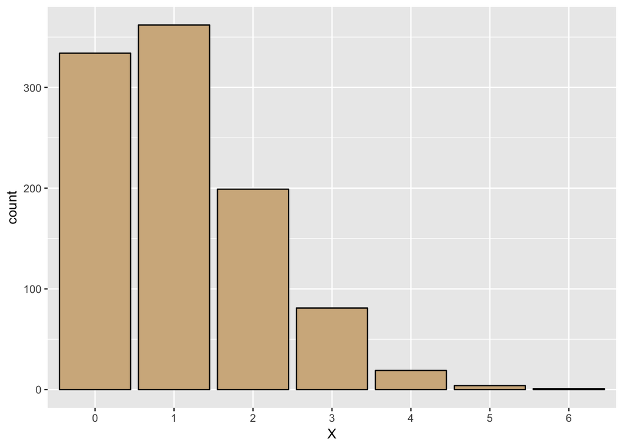

```
##    Min. 1st Qu.  Median    Mean 3rd Qu.    Max.
##   0.000   0.000   1.000   1.105   2.000   6.000
##  2.5% 97.5%
##     0     3
```

```r
x <- rpois(n=1000,lambda=1.1)
iHisto(x)
```

```r
mean(x==0)
```

```
## [1] 0.334
```

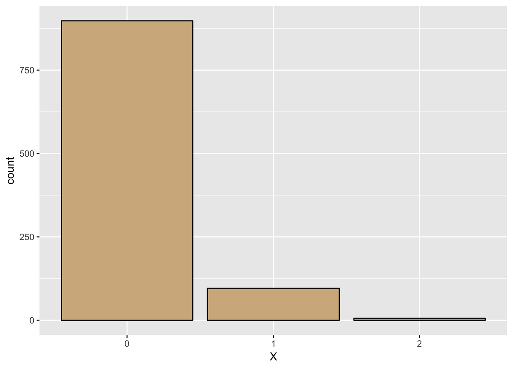

```
##    Min. 1st Qu.  Median    Mean 3rd Qu.    Max.
##   0.000   0.000   0.000   0.108   0.000   2.000
##  2.5% 97.5%
##     0     1
```

```r
x <- rpois(n=1000,lambda=0.1)
iHisto(x)
```

- Binomial
  - Range: [0, # of trials]
  - Parameters: size= number of trials; p = probability of positive outcome
  - Interpretation: Distribution of number of successful independent dichotomous trials, with constant p;

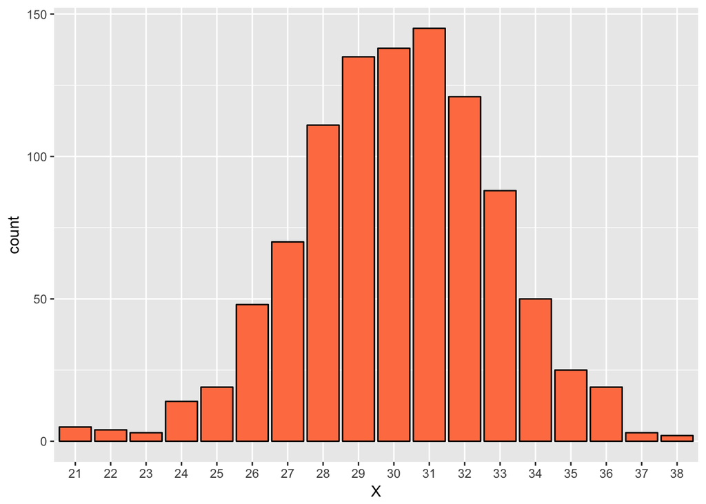

```
##    Min. 1st Qu.  Median    Mean 3rd Qu.    Max.
##   21.00   28.00   30.00   30.09   32.00   38.00
##  2.5% 97.5%
##    24    35
```

```r
x <- rbinom(n=1000,size=40,p=0.75)
iHisto(xData=x,fColor="coral")
```

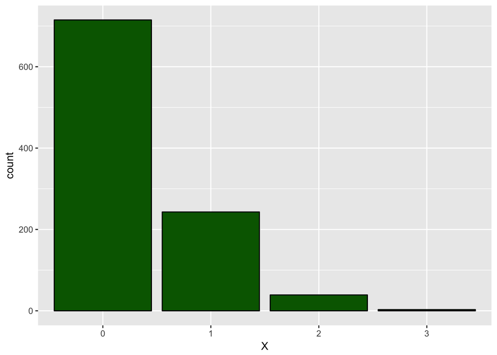

```
##    Min. 1st Qu.  Median    Mean 3rd Qu.    Max.
##    0.00    0.00    0.00    0.33    1.00    3.00
##  2.5% 97.5%
##     0     2
```

```r
x <- rbinom(n=1000,size=40,p=0.0075)
iHisto(xData=x,fColor="darkgreen")
```

- Multinomial
- a “balls in urns” analog of binomial
  - Range: [0, # of balls]
  - Parameters: n= number of random vectors to draw; size=number of balls to distribute; probs= probability weights for each of the different “urns”
  - Interpretation: Distribution of number of balls in each of the (unequal) urns

```r
z <- rmultinom(n=1,size=20,prob=c(0.2,0.7,0.1))
print(z)
```

```
##      [,1]
## [1,]    5
## [2,]   12
## [3,]    3
```

```r
# equivalent with sample function:
z <- sample(x=LETTERS[1:3],size=20,prob=c(0.2,0.7,0.1),replace=TRUE)
print(z)
```

```
##  [1] "B" "B" "C" "B" "B" "A" "B" "B" "B" "B" "B" "B" "C" "B" "A" "B" "B"
## [18] "C" "B" "C"
```

```r
table(z)
```

```
## z
##  A  B  C
##  2 14  4
```

- Negative Binomial
  - Range: [0, $\infty$]
  - Parameters: size=number of successes; p = probability of success
  - Interpretation: Distribution of number of failures in a series of independent Bernouli trials, each with p = probability of a success. Generates a discrete distribution that is more heterogeneous (“overdispersed”) than Poisson

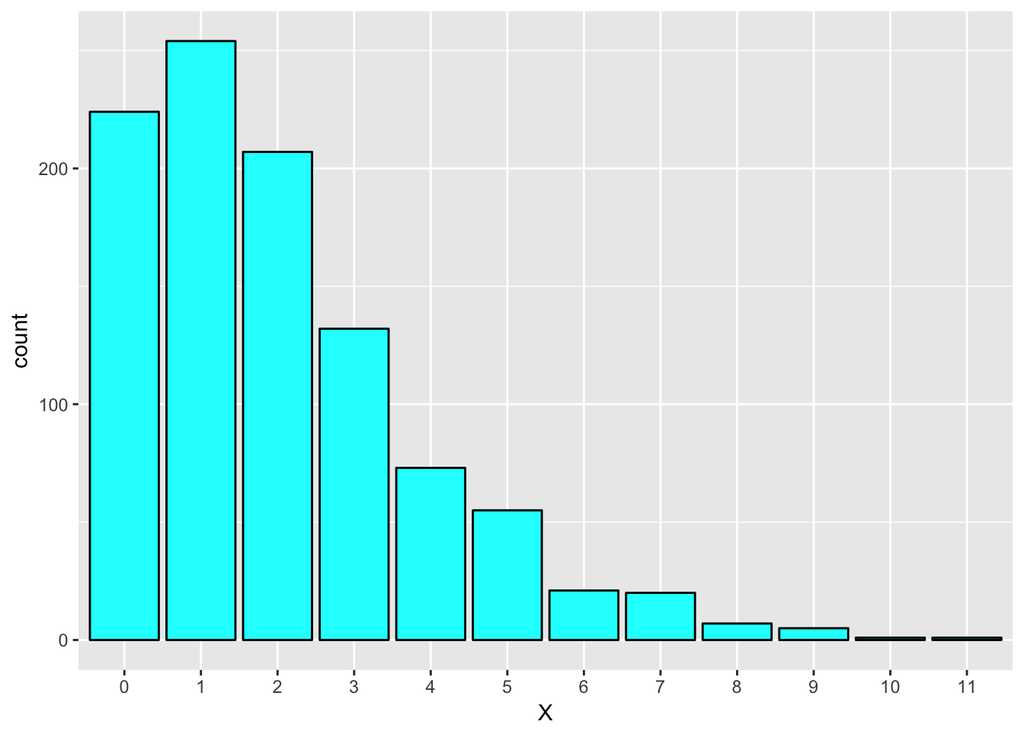

```
##    Min. 1st Qu.  Median    Mean 3rd Qu.    Max.
##   0.000   1.000   2.000   2.019   3.000  11.000
##  2.5% 97.5%
##     0     7
```

```r
z <- rnbinom(n=1000,size=2,p=0.5)
iHisto(z,fColor="cyan")
```

#### Continuous distributions

- Uniform
  - Range: [min,max]
  - Parameters: min = minimum boundary; max = maximum boundary
  - Interpretation: Distribution of a value that is equally likely within a specified range
- Normal
  - Range: [$-\infty,\infty$]
  - Parameters: mean = central tendency; SD = standard deviation
  - Interpretation: Symmetric bell-shaped curve with unbounded tails
- Gamma $\Gamma$
  - Range: [0,$\infty$]
  - Parameters: shape, scale
  - Interpretation: mean=$shape*scale$, variance=$shape*scale^2$; generates a variety of shapes (including normal and exponential) for positive continuous variables
- Beta $\beta$
  - Range: [0,1] (can be rescaled to any range by simple multiplication and addition)
  - Paramters: shape1, shape2
  - Interpretation: if shape1 and shape 2 are integers, interpret as a coin toss, with shape1 = # of successes + 1, shape2 = # of failures + 1. Gives distribution of value of p, estimated from data, which can range from exponential through uniform through normal (but all are bounded). Setting shape1 and shape2 <1 yields u-shaped distributions.